**ANALYZING AND PREDICTING EMPLOYEE ATTRITION RATE**

[figure not shown]

# Introduction

An in-depth exploration of fundamental data analytics principles to forecast the rate of employee attrition within the organization, as well as to determine the factors that influence an employee's decision to depart from the company.

## Business use case (What are we solving for?)

- Predicting individual employee attrition
- Depicting important factors for an employee to leave an organization
- Improving employee retention

## Goals/metrics

Find the probability of an employee leaving the firm for the next five years and identify how to improve employee retention.

## About dataset

This is a HR Analytics dataset about employee attrition. The dataset contains the following features:

- satisfaction_level
- last_evaluation
- number_project
- average_monthly_hours
- time_spend_company
- Work_accident left
- promotion_last_5years
- sales
- salary

# Import libraries, read and preview data

```python
import pandas as pd
import matplotlib.pyplot as plt
import seaborn as sns
import numpy as np
from matplotlib import rcParams
from scipy.stats import norm

from sklearn.preprocessing import StandardScaler
from sklearn.feature_extraction import DictVectorizer
from sklearn.linear_model import LogisticRegression
from sklearn.svm import SVC
import xgboost as xgb
from sklearn.neighbors import KNeighborsClassifier
from sklearn.model_selection import train_test_split, GridSearchCV
from sklearn.pipeline import Pipeline
from sklearn.base import BaseEstimator, TransformerMixin
from sklearn.ensemble import RandomForestClassifier, AdaBoostClassifier
from sklearn.tree import DecisionTreeClassifier

import pingouin
```

```python
# Set default settings
sns.set_style('whitegrid')
rcParams['figure.figsize'] = [7,5]
rcParams['axes.titlesize'] = 14
rcParams['axes.titleweight'] = 'bold'
rcParams['axes.labelsize'] = 13
rcParams['axes.labelweight'] = 'bold'
```

```python
# Read dataset
hr_data = pd.read_csv("data/HR_Data.csv")

# Preview dataset
display(hr_data.head())
```

|  | satisfaction_level | last_evaluation | number_project | average_montly_hours | time_spend_company | Work_accident | left | promotion_last_5years | sales | salary |
| --- | --- | --- | --- | --- | --- | --- | --- | --- | --- | --- |
| 0 | 0.38 | 0.53 | 2 | 157 | 3 | 0 | 1 | 0 | sales | low |
| 1 | 0.80 | 0.86 | 5 | 262 | 6 | 0 | 1 | 0 | sales | medium |
| 2 | 0.11 | 0.88 | 7 | 272 | 4 | 0 | 1 | 0 | sales | medium |
| 3 | 0.72 | 0.87 | 5 | 223 | 5 | 0 | 1 | 0 | sales | low |
| 4 | 0.37 | 0.52 | 2 | 159 | 3 | 0 | 1 | 0 | sales | low |

```python
# Preview dataset propertises
hr_data.info()
```

```
<class 'pandas.core.frame.DataFrame'>
RangeIndex: 14999 entries, 0 to 14998
Data columns (total 10 columns):
 #   Column                 Non-Null Count  Dtype
---  ------                 --------------  -----
 0   satisfaction_level     14999 non-null  float64
 1   last_evaluation        14999 non-null  float64
 2   number_project         14999 non-null  int64
 3   average_montly_hours   14999 non-null  int64
 4   time_spend_company     14999 non-null  int64
 5   Work_accident          14999 non-null  int64
 6   left                   14999 non-null  int64
 7   promotion_last_5years  14999 non-null  int64
 8   sales                  14999 non-null  object
 9   salary                 14999 non-null  object
dtypes: float64(2), int64(6), object(2)
memory usage: 1.1+ MB
```

```python
# Correct the column names
hr_data = hr_data.rename(columns={'average_montly_hours':'average_monthly_hours'})
```

# Exploratory Data Analysis

## What is the probabability that an employee leaves the company?

By randomly selecting a sample size equivalent to that of the employees' dataset, and then repeatedly performing the experiment 1000 times with replacement, we can establish a sampling distribution that comprises probabilities of employees departing. By computing the average of the replicates, we can obtain an accurate representation of the population, thereby determining the probability of an employee leaving the organization.

There is a `23.83%` chance that an employee will leave the company.

```python
prob_leaving_list = []
np.random.seed(987)
for i in range(1000):

    prob_leaving_list.append(hr_data.sample(frac = 1.0, replace = True)['left'].value_counts(normalize = True)[1])

prob_leaving = np.mean(prob_leaving_list)
print(f'Probability of an employee leaving is {100*prob_leaving:,.2f}%')
```

```
Probability of an employee leaving is 23.83%
```

## Visualizing the sampling distribution

Visualizing the sampling distribution provides us with a precise representation of the range of values that are probable to emerge within our confidence intervals.

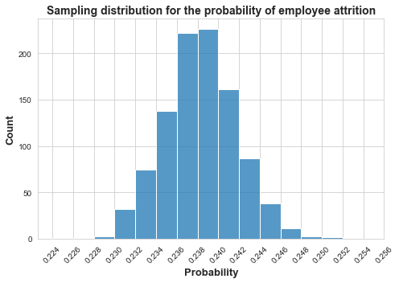

```python
fig = plt.figure()
sns.histplot(prob_leaving_list, bins = np.arange(0.224,0.254, 0.002))
plt.title('Sampling distribution for the probability of employee attrition')
plt.ylabel('Count')
plt.xlabel('Probability')
plt.xticks(np.arange(0.224,0.258, 0.002), rotation = 45)
plt.tight_layout()
fig.savefig('hr.png', dpi = 320)
plt.show()
```

## Confidence Intervals

In order to determine the level of certainty with which we can assert that the probability of an employee leaving is 0.2383, we will employ two distinct techniques: the quantile method and the standard error method. Notably, these methods should yield identical outcomes, thus bolstering our confidence in the veracity of our findings.

### The Quantile Method

The quantile method is a statistical technique used in data analysis to estimate the confidence interval of a population parameter. It involves computing the confidence interval by identifying the upper and lower bounds of a range of values that encompasses a specific percentage of the sample data.

```python
# Calculate the lower quartile
lower_quant = np.quantile(prob_leaving_list, 0.025)

# Calculate the upper quartile
upper_quant = np.quantile(prob_leaving_list, 0.975)

print(f'Lower limit is {lower_quant:,.5f} and upper limit is {upper_quant:,.5f}')
```

```
Lower limit is 0.23135 and upper limit is 0.24522
```

### The Standard Error Method

The standard error method estimates the confidence interval of a population parameter by computing the confidence interval by using the standard error, which is the standard deviation of the sampling distribution of the mean or proportion.

The result is the same as that of the quantile method with the probability of an employee leaving is between `23.14%` and `24.51%`

```python
# Compute the mean
point_estimate = np.mean(prob_leaving_list)

# Compute the sample standard error
standard_error = np.std(prob_leaving_list, ddof = 1)

# Compute the lower limit
lower_se = norm.ppf(0.025, loc = point_estimate, scale = standard_error)

# Compute the upper limit
upper_se = norm.ppf(0.975, loc = point_estimate, scale = standard_error)

print(f'We can say with 95% confidence that the probability of an employee leaving is between {100*lower_se:,.2f}% and {100*upper_se:,.2f}%')
```

```
We can say with 95% confidence that the probability of an employee leaving is between 23.14% and 24.51%
```

## Salary

Our analysis has revealed that the proportion of employees who left the organization is highest among those who received a `low` salary, while the lowest proportion was observed among employees who received a `high` salary. These findings offer insight into relationship between salary levels and employee attrition rates, and underscore the importance of fair compensation in retaining employees.

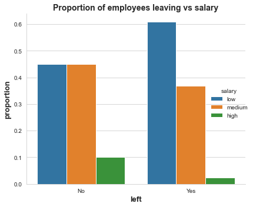

```python
hr_salary = pd.DataFrame(hr_data.groupby('left').salary.value_counts(normalize = True))
hr_salary.columns = ['proportion']
hr_salary = hr_salary.reset_index()

sns.catplot(x = 'left', y = 'proportion', hue = 'salary', data = hr_salary, kind = 'bar')
plt.xticks([0,1],['No','Yes'])
plt.title('Proportion of employees leaving vs salary')
plt.tight_layout()
plt.show()
```

## Promotion in the last five years

Only 2% of all employees have been promoted in the last 5 years.

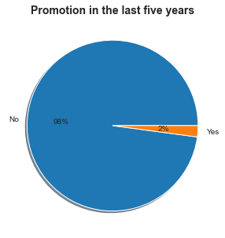

```python
plt.pie(hr_data.promotion_last_5years.value_counts(), autopct = '%.0f%%', labels = ['No','Yes'], shadow = True)
plt.title('Promotion in the last five years')
plt.show()
```

## Sales

As per the observations derived from the countplot, the number of employees who have left or continued to stay in the organization appears to be proportionate to the total headcount in each department.

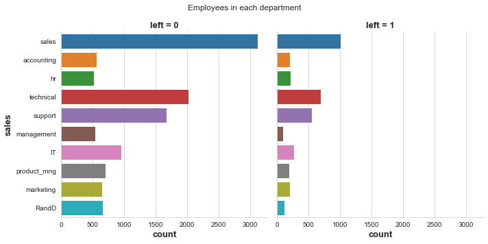

```python
g = sns.catplot(y = 'sales', data = hr_data, kind = 'count', col = 'left')
g.fig.suptitle('Employees in each department')
plt.tight_layout()
plt.show()
```

## Last evaluation

Our analysis revealed a slight variation in the median evaluation scores between employees who left and those who stayed, with respective values of 0.79 and 0.71. This small difference could be insignificant since the mean variation is very small.

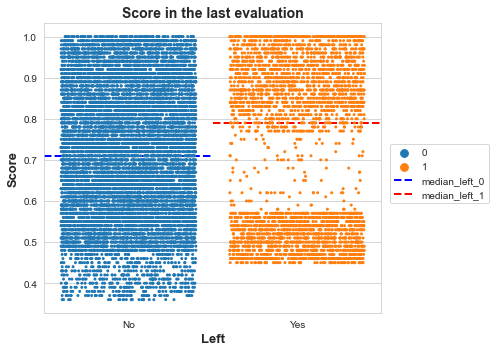

```python
sns.stripplot(x = 'left', y = 'last_evaluation', data = hr_data, hue = 'left', jitter = 0.4, size = 3)
plt.title('Score in the last evaluation')
plt.ylabel('Score')
plt.xlabel('Left')
plt.axhline(hr_data.loc[hr_data.left == 0, 'last_evaluation'].median(),xmin = 0, xmax=0.5, ls = '--', lw =2, color = 'blue', label = 'median_left_0')
plt.axhline(hr_data.loc[hr_data.left == 1, 'last_evaluation'].median(),xmin = 0.5, xmax=1, ls = '--', lw =2, color = 'red', label = 'median_left_1')
plt.xticks([0,1],['No','Yes'])
#plt.ylim([0,1.2])
plt.legend(bbox_to_anchor = [1.01,0.6])
plt.tight_layout()
plt.show()
```

## Work accident

A significantly smaller proportion of employees who left the organization (4.7%) had been involved in accidents, compared to those who decided to stay (17.5%). Additionally, a markedly larger fraction of employees who left (95%) had not been involved in any accidents, as opposed to those who stayed (82.5%).

```python
hr_data.groupby('left')['Work_accident'].value_counts(normalize = True) *100
```

```
left  Work_accident
0     0                82.499125
      1                17.500875
1     0                95.267432
      1                 4.732568
Name: Work_accident, dtype: float64
```

## Satisfaction level vs salary

While the satisfaction levels of employees who left the organization were relatively lower than those who decided to stay, there was little variance in the satisfaction levels among employees of different salary grades. For example, among employees who left, the satisfaction levels of those receiving low, medium, and high salaries were 0.41, 0.41, and 0.43, respectively. These findings suggest that factors beyond just salary levels may have played a significant role in determining employee satisfaction and ultimately, their decision to leave. Identifying and addressing such factors can be a key step in enhancing employee satisfaction and retention rates.

```python
hr_data.pivot_table(index = 'salary',columns = 'left', values = 'satisfaction_level', aggfunc = 'median')
```

| left salary | 0 | 1 |
| --- | --- | --- |
| high | 0.67 | 0.43 |
| low | 0.69 | 0.41 |
| medium | 0.69 | 0.41 |

## Satisfaction level vs average monthly hours

The satisfaction level of employees was not linearly dependent on the average monthly hours.

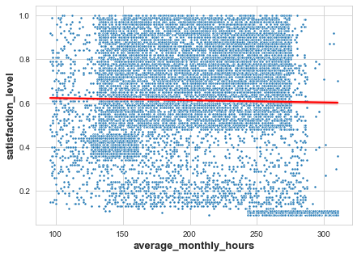

```python
sns.scatterplot(x = 'average_monthly_hours', y = 'satisfaction_level', data = hr_data, marker = '.')
sns.regplot(x = 'average_monthly_hours', y = 'satisfaction_level', data = hr_data, scatter = False, color = 'red')
plt.show()
```

## Satisfaction level vs promotion

There is no discernible difference in the satisfaction levels between employees who were promoted in the last five years and those who were not. This finding suggests that promotion alone may not be a significant factor in determining employee satisfaction levels. Further exploration and analysis of additional factors may be necessary to better understand the complex interplay between employee satisfaction and promotions, which can potentially inform more effective retention and career development strategies.

```python
hr_data.pivot_table(index = 'promotion_last_5years',columns = 'left', values = 'satisfaction_level', aggfunc = 'median')
```

| left promotion_last_5years | 0 | 1 |
| --- | --- | --- |
| 0 | 0.690 | 0.41 |
| 1 | 0.695 | 0.44 |

# Preprocessing

## Missing values

Our data has no missing values.

```python
hr_data.isna().sum()
```

```
satisfaction_level       0
last_evaluation          0
number_project           0
average_monthly_hours    0
time_spend_company       0
Work_accident            0
left                     0
promotion_last_5years    0
sales                    0
salary                   0
dtype: int64
```

## Column types

Convert variables to appropriate data types. `promotion_last_5years` and `Work_accident` are binary columns with 0s and 1s. We will convert them to string so that they are not included in numerical variables that will undergo standardization.

```python
hr_data['promotion_last_5years'] = hr_data['promotion_last_5years'].astype('object')
hr_data['Work_accident'] = hr_data['Work_accident'].astype('object')
```

### Create numeric and categorical columns

Numeric columns are of integer or float data types. Category columns are of object or string data types

```python
# Split dataset to dependent and independent variables
X = hr_data.drop('left', axis = 1)
y = hr_data['left']

# Select category and numeric columns
columns_numeric = X.select_dtypes(include = ['float', 'int']).columns.tolist()
columns_category = X.select_dtypes(include= ['object']).columns.tolist()
```

## Split dataset to train and validation sets

```python
X_train, X_test, y_train, y_test = train_test_split(X, y, stratify = y, random_state = 987)
```

```python
# Create the dictifier transformer
class Dictifier(BaseEstimator, TransformerMixin):
    "The dictifier class converts a dataframe to a dictionary to allow using the dict vectorizer transformer"
    def __init__(self):
        pass

    def fit(self, df):
        """Mock method"""
        return self

    def transform(self, df):
        return df.to_dict('records')
```

## Standardization and encoding

Encoding categorical columns and standardizing numeric columns.

```python
# Categorical pipeline that converts to dictionary and encodes the categories
cat_steps = [('dictifier',Dictifier()),('vectorizer',DictVectorizer(sort = False, sparse = False))]
num_steps = [('scaler', StandardScaler())]

# Numeric pipeline to standardize numeric columns
num_pipe = Pipeline(num_steps)
cat_pipe = Pipeline(cat_steps)

# Fit and transform the training set
x_train_cat_vec = cat_pipe.fit_transform(X_train[columns_category])
X_train_num_sc = num_pipe.fit_transform(X_train[columns_numeric])

# Transform the test set
x_test_cat_vec = cat_pipe.transform(X_test[columns_category])
X_test_num_sc = num_pipe.transform(X_test[columns_numeric])
```

### Join the numeric and categorical columns

```python
# Create dataframes from training set
X_train_cat = pd.DataFrame(x_train_cat_vec, columns = cat_pipe['vectorizer'].feature_names_)
X_train_num = pd.DataFrame(X_train_num_sc, columns = columns_numeric)

# Create dataframes from test set
X_test_cat = pd.DataFrame(x_test_cat_vec, columns = cat_pipe['vectorizer'].feature_names_)
X_test_num = pd.DataFrame(X_test_num_sc, columns = columns_numeric)

# Join category and numeric columns
X_train = pd.concat([X_train_num, X_train_cat], axis = 1)
X_test = pd.concat([X_test_num, X_test_cat], axis = 1)
```

# Answering business questions

## Can we predict an individual attrition?

Can we accurately predict an employee's likelihood of leaving the organization based on the features present in the dataset? To accomplish this, we evaluated a variety of different models and assessed their effectiveness in accurately classifying employee outcomes. Ultimately, our analysis indicated that the random forest classifier was the most effective model for this task, yielding an impressive accuracy rate of `99%` when predicting previously unseen data.

```python
logreg = LogisticRegression()
xgb_cl = xgb.XGBClassifier()
svc = SVC()
knn = KNeighborsClassifier()
rf = RandomForestClassifier()
ada = AdaBoostClassifier()
dt = DecisionTreeClassifier()

classifiers = [('Logistic Regression',logreg),('Xgboost',xgb_cl),('Support vector',svc),
               ('K_Neighbors',knn),('Random forest',rf),('Decision tree',dt),('Adaboost',ada)]

accuracy_score = []
for clf_name, clf in classifiers:
    clf.fit(X_train, y_train)
    y_pred = clf.predict(X_test)
    accuracy = (y_pred == y_test).sum()/len(y_test)
    accuracy_score.append({'classifier':clf_name, 'accuracy':accuracy})

accuracy_df = pd.DataFrame(accuracy_score)
accuracy_df.sort_values(by='accuracy', ascending = False)
```

|  | classifier | accuracy |
| --- | --- | --- |
| 4 | Random forest | 0.991467 |
| 1 | Xgboost | 0.989333 |
| 5 | Decision tree | 0.978133 |
| 2 | Support vector | 0.967467 |
| 6 | Adaboost | 0.960533 |
| 3 | K_Neighbors | 0.948533 |
| 0 | Logistic Regression | 0.792533 |

```python
random_forest = RandomForestClassifier(random_state = 987)
random_forest.fit(X_train, y_train)
y_pred = random_forest.predict(X_test)
accuracy = (y_pred == y_test).sum()/len(y_test)
print(f'The random forest classifier has an accuracy of {accuracy}')
```

```
The random forest classifier has an accuracy of 0.9909333333333333
```

## Which are the most important factors for an employee to leave the organization?

### Using random forest

Random Forest's `feature_importances_` attribute provides insight into the relative importance of each feature in contributing to the overall prediction accuracy of the model. It expresses the percentage contribution of each feature such that the larger the feature importance value, the greater the contribution of that particular feature to the overall predictive power of the model.

The most important features contributing towards leaving of employees are:

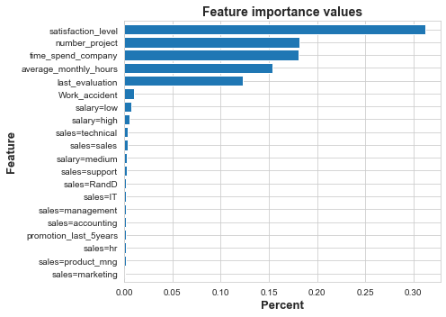

```python
pd.Series(rf.feature_importances_, index = rf.feature_names_in_).sort_values().plot(kind='barh', width = 0.8)
plt.xlabel('Percent')
plt.ylabel('Feature')
plt.title('Feature importance values')
plt.tight_layout()
plt.show()
```

### Using xgboost

Xgboost has a `plot_importance` method that takes the estimator as an argument and plots the importance of each feature using an F-score value. The larger the score of a feature, the larger its contribution. Using the xgboost classifier, the highest contributors are:

```
xgboost has an accuracy of 0.9893333333333333
```

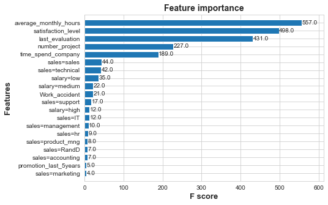

```python
xgb_cl = xgb.XGBClassifier(objective= 'binary:logistic', random_state = 987)
xgb_cl.fit(X_train, y_train)
y_pred = xgb_cl.predict(X_test)
accuracy = (y_pred == y_test).sum()/len(y_test)
print(f'xgboost has an accuracy of {accuracy}')

xgb.plot_importance(xgb_cl, height = 0.8)
plt.show()
```

### Which features?

In conclusion, both models concur that the five features below are the most important factors for an employee to leave the organization:

- Average monthly hours
- Satisfaction level
- Last evaluation
- Time spent at company
- Number projects.

To verify this, we trained two models using the same five features and evaluated their predictive accuracy. The results indicate that both models achieved an accuracy of `99%` and `98%` for the random forest and xgboost respectively. These values are consistent with the accuracy achieved when using all features. Therefore, this confirms that the five selected features are the most crucial in determining employee attrition.

```python
xgboost_cl = xgb.XGBClassifier(objective= 'binary:logistic', random_state = 987)
random_forest = RandomForestClassifier(random_state = 987)

features = ['average_monthly_hours','satisfaction_level','last_evaluation','number_project','time_spend_company']
classifiers = [('xgboost',xgboost_cl),('random forest',random_forest)]

for clf_name, clf in classifiers:
    clf.fit(X_train[features], y_train)
    y_pred = clf.predict(X_test[features])
    accuracy = (y_pred == y_test).sum()/len(y_test)
    print(f'{clf_name} has an accuracy of {accuracy:,.4f}')
```

```
xgboost has an accuracy of 0.9883
random forest has an accuracy of 0.9923
```

## How can employee retention be improved?

Given that we have identified the key factors contributing to employee attrition, what strategies can be implemented to improve employee retention based on these factors? To answer that, we need to know if:

- The employees who leave are less satisfied than those that stay?
- The employees who leave spend more time in the company than those that stay?
- The number of projects of employees that leave is different from those that stay?
- The average monthly hours for the employees that leave is more than those that stay?
- The last evaluation score was lower for employees that leave than for those that stay?

### Are the employees who leave less satisfied than those that stay?

**Hypothesis**

- H<sub>0</sub> Satisfaction level of employees who leave is equal to those that stay.
- H<sub>1</sub>: Satisfaction level is lower for employees that leave.

Based on the boxplot, the median satisfaction level of employees who left the company is lower (median satisfaction level = 0.41) compared to those who stayed (median satisfaction level = 0.69). Additionally, the average satisfaction level of employees who left is also lower at 0.44 compared to employees who did not leave, whose average satisfaction level is 0.67. The maximum satisfaction level for employees is higher for those who stayed (1.0) compared to those who left (0.92). These results suggest that a higher satisfaction level is associated with lower employee attrition rates.

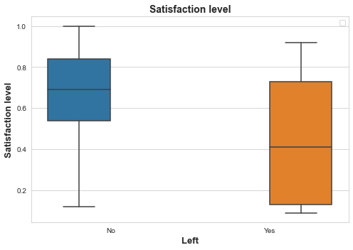

```python
sns.boxplot(x = 'left', y = 'satisfaction_level', data = hr_data, hue = 'left')
plt.title('Satisfaction level')
plt.xlabel('Left')
plt.ylabel('Satisfaction level')
plt.xticks([0,1],['No','Yes'])
plt.legend("")
plt.tight_layout()
plt.show()
```

**Is the difference in the satisfaction level between employees that left and those that did not significant?**

Upon conducting further analysis using anova test, the resulting p-value (p-unc) was found to be 0.00, which is less than the significance level of 0.05. This indicates with 95% confidence that the satisfaction level of employees who left is significantly lower than that of employees who stayed. Hence, we reject the null hypothesis (H<sub>0</sub>) and accept the alternative hypothesis (H<sub>1</sub>), which states that the satisfaction level is lower for employees who leave.

```python
pingouin.anova(dv = 'satisfaction_level', between = 'left',data = hr_data)
```

|  | Source | ddof1 | ddof2 | F | p-unc | np2 |
| --- | --- | --- | --- | --- | --- | --- |
| 0 | left | 1 | 14997 | 2663.881285 | 0.0 | 0.150835 |

### Do employees that leave spend more time in the company than those that stay?

**Hypothesis**

- H<sub>0</sub>: Time spent in the company by employees that left and those that stayed is equal
- H<sub>1</sub>: Time spent in the company by employees that left is more

According to the boxplot, employees who left the company had a longer average tenure than those who stayed, indicated by the median of 4 years and 3 years respectively. Furthermore, the average tenure of employees who left is higher than those who stayed, with 3.9 years and 3.4 years respectively. The maximum tenure for employees who left the company is 6 years, whereas the maximum for employees who stayed is 10 years.

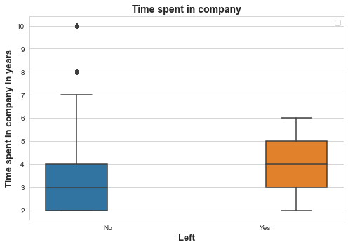

| left | count | mean | std | min | 25% | 50% | 75% | max |
| --- | --- | --- | --- | --- | --- | --- | --- | --- |
| 0 | 11428.0 | 3.380032 | 1.562348 | 2.0 | 2.0 | 3.0 | 4.0 | 10.0 |
| 1 | 3571.0 | 3.876505 | 0.977698 | 2.0 | 3.0 | 4.0 | 5.0 | 6.0 |

```python
sns.boxplot(y='time_spend_company',x='left', data = hr_data, hue = 'left')
plt.xlabel('Left')
plt.ylabel('Time spent in company in years')
plt.title('Time spent in company')
plt.xticks([0,1],['No','Yes'])
plt.legend("")
plt.tight_layout()
plt.show()

hr_data.groupby('left')['time_spend_company'].describe()
```

**Is the difference in time spent in the company by employees that stayed and those that left significant?**

Based on the ANOVA tests, we can conclude with 95% confidence that there is a significant difference between the time spent at the company by employees who left and those who did not, as indicated by a p-value of 0.000. Therefore, we reject the null hypothesis in favor of the alternative hypothesis that states the time spent in the company by employees who left is greater. This suggests that employees who have been with the company for a longer time are more likely to leave than those who are newly recruited.

```python
pingouin.anova(data = hr_data, dv = 'time_spend_company', between = 'left')
```

|  | Source | ddof1 | ddof2 | F | p-unc | np2 |
| --- | --- | --- | --- | --- | --- | --- |
| 0 | left | 1 | 14997 | 321.277313 | 4.207680e-71 | 0.020973 |

### The number of projects by employees that left is not equal to those that stayed

**Hypothesis**

- H<sub>0</sub>: The number of projects by employees that stayed and those that left is equal
- H<sub>1</sub>: The number of projects by employees that stayed is not equal to those that left

Summary statistics reveal that there is no significant difference in the median number of projects completed by employees who left the company and those who remained. However, there is a slight disparity in their means. The violin plot indicates that a considerable proportion of employees who left the company worked on only two projects, evidenced by the bulge at the value of 2. In contrast, most employees who stayed at the company worked on three or four projects, with a minority working on two or six projects. This observation is consistent with the summary statistics, which indicate that up to the 40th percentile of employees who stayed at the company worked on three projects, while those who left the company worked on only two projects.

| left | count | mean | std | min | 0% | 10% | 30% | 40% | 50% | 60% | 70% | 90% | max |
| --- | --- | --- | --- | --- | --- | --- | --- | --- | --- | --- | --- | --- | --- |
| 0 | 11428.0 | 3.786664 | 0.979884 | 2.0 | 2.0 | 3.0 | 3.0 | 3.0 | 4.0 | 4.0 | 4.0 | 5.0 | 6.0 |
| 1 | 3571.0 | 3.855503 | 1.818165 | 2.0 | 2.0 | 2.0 | 2.0 | 2.0 | 4.0 | 5.0 | 5.0 | 6.0 | 7.0 |

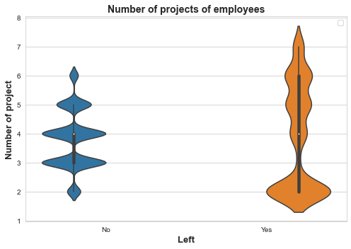

```python
display(hr_data.groupby('left')['number_project'].describe(percentiles=[0,.1,.3,.4,.6,.7,.9]))
print()
sns.violinplot(x = 'left', y = 'number_project', data = hr_data, hue = 'left')
plt.ylabel('Number of project')
plt.xlabel('Left')
plt.title('Number of projects of employees')
plt.xticks([0,1],['No','Yes'])
plt.legend("")
plt.tight_layout()
plt.show()
```

**Are the differences significant?**

Based on the t-test results with a p-value of 0.03, we can conclude with 95% confidence that there is a significant difference in the number of projects worked on by employees who left the company and those who stayed. Although the summary statistics suggest no difference in medians, further analysis using t-tests accounts for the distribution of the data and reveals differences. Therefore, we reject the null hypothesis (H<sub>0</sub>) in favor of the alternative hypothesis (H<sub>1</sub>) which states that the number of projects worked on by employees who stayed is not equal to those who left.

```python
proj_left = hr_data.loc[hr_data.left == 1, 'number_project']
proj_stay = hr_data.loc[hr_data.left == 0, 'number_project']

pingouin.ttest(x = proj_left, y = proj_stay, alternative = 'two-sided', paired = False, confidence = 0.95)
```

|  | T | dof | alternative | p-val | CI95% | cohen-d | BF10 | power |
| --- | --- | --- | --- | --- | --- | --- | --- | --- |
| T-test | 2.166342 | 4236.542893 | two-sided | 0.030341 | [0.01, 0.13] | 0.055862 | 0.225 | 0.829884 |

### The average monthly hours for the employees that leave is more than those that stay?

- H<sub>0</sub>: The average monthly hours for employees that left and those that stayed is the same
- H<sub>1</sub>: The average monthly hours for employees that left is more

Employees who left the company had worked for longer hours than those who stayed, with a median of 224 hours compared to 198 hours. The average number of hours worked was also higher among employees who left, with an average of 207 hours compared to 199 hours for those who stayed. Furthermore, it was observed that the minimum and maximum number of hours worked were higher among employees who left, suggesting that these employees tended to work for longer hours.

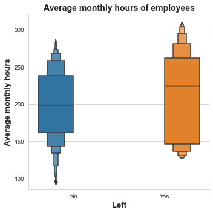

```
        count        mean        std    min    25%    50%    75%    max
left
0     11428.0  199.060203  45.682731   96.0  162.0  198.0  238.0  287.0
1      3571.0  207.419210  61.202825  126.0  146.0  224.0  262.0  310.0
```

```python
sns.catplot(x = 'left', y = 'average_monthly_hours', data = hr_data, kind = 'boxen', hue='left')
plt.title('Average monthly hours of employees')
plt.xlabel('Left')
plt.ylabel('Average monthly hours')
plt.xticks([0,1],['No','Yes'])
plt.tight_layout()
plt.show()
print()
print(hr_data.groupby('left')['average_monthly_hours'].describe())
```

**Is this difference significant?**

Based on the results of the t-test analysis, we can conclude with 95% confidence that the average monthly working hours of employees who left the company is significantly higher than that of employees who stayed, as indicated by a p-value of 0.000, which is less than the predefined significance level of 0.05. The estimated difference between the two groups is at least 6.5 hours. Therefore, we reject the null hypothesis (H<sub>0</sub>) in favor of the alternative hypothesis (H<sub>1</sub>) that the average monthly working hours of employees who left the company is greater.

```python
left_employees_hours = hr_data[hr_data['left'] == 1]['average_monthly_hours']
stayed_employees_hours = hr_data[hr_data['left'] == 0]['average_monthly_hours']

pingouin.ttest(x = left_employees_hours, y = stayed_employees_hours, alternative = 'greater', confidence = 0.95)
```

|  | T | dof | alternative | p-val | CI95% | cohen-d | BF10 | power |
| --- | --- | --- | --- | --- | --- | --- | --- | --- |
| T-test | 7.532289 | 4875.061919 | greater | 2.953527e-14 | [6.53, inf] | 0.167792 | 8.236e+10 | 1.0 |

### The last evaluation score was lower for employees that leave than for those that stay?

- H<sub>0</sub>: The last evaluation score for employees that left and those that stayed is the same
- H<sub>1</sub>: The last evaluation score for employees that left is not the same

```python
hr_data.groupby('left')['last_evaluation'].describe()
print()
pingouin.pairwise_tests(dv = 'last_evaluation', between = 'left', data = hr_data, alternative = 'two-sided')
```

|  | Contrast | A | B | Paired | Parametric | T | dof | alternative | p-unc | BF10 | hedges |
| --- | --- | --- | --- | --- | --- | --- | --- | --- | --- | --- | --- |
| 0 | left | 0 | 1 | False | True | -0.725342 | 5154.893462 | two-sided | 0.468275 | 0.028 | -0.015418 |

### Recommendations

1. Our analysis in section 4 indicates that employees who left the company were less satisfied than those who stayed. To improve employee retention, it is recommended that the company takes measures to ensure that its employees are satisfied. Our findings also suggest that monthly working hours, salary, and promotions may not be significant factors affecting employee satisfaction. Further research is recommended to identify factors to improve employee satisfaction.
2. Our analysis indicates that employees who left had longer tenures with the company. Studies have shown that long-serving employees may leave due to inadequate pay, lack of opportunities for career advancement, and limited growth prospects. Therefore, further research is recommended to identify strategies to retain long-serving employees.
3. It is recommended that the company ensure the fair distribution of projects among employees to promote equity and minimize employee dissatisfaction.
4. Our analysis suggests that employees who left worked longer hours per month than those who stayed, indicating the possibility of overwork. To address this, the company should consider implementing standardized working hours and offering overtime pay for employees who work additional hours.